## bimDataOne

We will use the same dataset “bmiDataOne” for all the one-stage DynTxRegime methods for estimating optimal treatment regime. This dataset is excerpted from the bmiData in the DynTxRegime package to mimic a single-stage SMART of body mass index (BMI) reduction with two treatment options at the decision point. The full dataset bmiData was generated based on a clinical trial studying the effect of meal replacements on weight loss and BMI reduction in obese adolescents; see Berkowitz et al. (2010) for a complete description of the original randomized trial.

In the dataset “bmiDataOne”“, the baseline covariates include the following information of the patient: gender (gender), race (race), his/er parent’s BMI (parentBMI), baseline BMI(baselineBMI). Each patient’s treatment at the decision point (A1) is included. The treatment was randomized to meal replacement (MR) or conventional diet (CD) at the single stage with probability 0.5. His/er BMI collected after 4-month treatment (month4BMI) is also included. This generated dataset is complete, as we implement the method after missing data have been imputed appropriately.

Here is a glimpse of the dataset.

```r
# Data
head(bmiDataOne)
```

```
##   gender race parentBMI baselineBMI month4BMI A1
## 1      0    1  31.59683    35.84005  34.22717 CD
## 2      1    0  30.17564    37.30396  36.38014 CD
## 3      1    0  30.27918    36.83889  34.42168 MR
## 4      1    0  27.49256    36.70679  32.52011 CD
## 5      1    1  26.42350    34.84207  33.72922 CD
## 6      0    0  29.30970    36.68640  32.06622 MR
```

There are 210 subjects in the dataset.

```r
dim(bmiDataOne)
```

```
## [1] 210   6
```

We code the two level treatments as “CD = 0” and “MR = 1”, and show a matrix of scatterplots of this dataset.

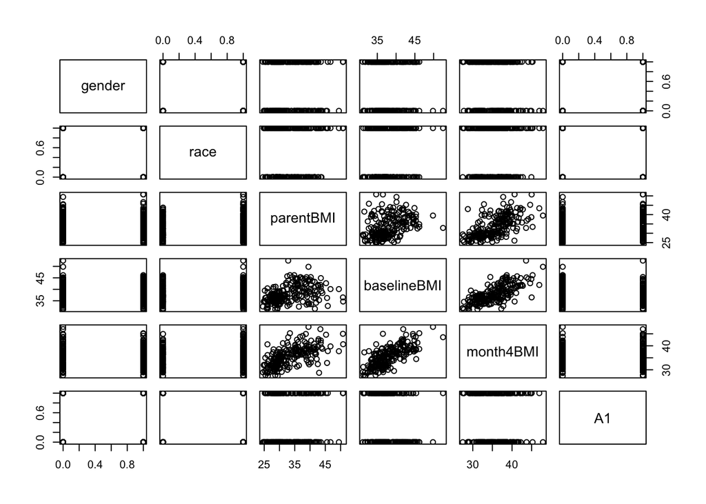

```r
#----------------------------------------------------#
# Recast treatment variables to (0,1) and scattlerplots
#----------------------------------------------------#
bmiDataOne$A1[which (bmiDataOne$A1=="MR")] <- 1L
bmiDataOne$A1[which (bmiDataOne$A1=="CD")] <- 0L
bmiDataOne$A1 <- as.integer(bmiDataOne$A1)
pairs(data.matrix(bmiDataOne, rownames.force = NA))
```